# Classification: Decision Trees and Random Forest

Vijay K. Gurbani, Ph.D., Illinois Institute of Technology

#### German credit dataset with 21 variables and 1,000 records. The dependent target is Creditability, which is 1 or 0 depending on whether a loan is to be granted or not, respectively, to a customer. The dataset is available at https://sites.google.com/site/pocketecoworld/german_credit.csv

#### We will classify the dataset using Decision Trees and Random Forests.

#### **If you do not have package ‘randomForest’ installed, make sure you install it first.**

```r
library(rpart)
library(caret)
library(rpart.plot)
library(randomForest)
setwd("~/Desktop/Assignments&Coursework/422/Hw-2-March4/")
set.seed(1122)
df <- read.csv("german_credit.csv", sep=",", comment.char = "#")
# Note: You can also read the file directly using a URL:
# df <- read.csv("https://sites.google.com/site/pocketecoworld/german_credit.csv")
```

#### Coerce the response variable to be a factor.

```r
df$Creditability <- as.factor(df$Creditability)
```

#### Create the training and test datasets.

```r
indx <- sample(1:nrow(df), 200)
train <- df[-indx, ]
test <- df[indx, ]
```

#### Let’s see the distribution of the class labels in the training and testing datasets

```r
cat("Training dataset class label distribution")
```

```
Training dataset class label distribution
```

```r
table(train$Creditability)
```

```
  0   1
240 560
```

```r
cat("\nTest dataset class label distribution")
```

```
Test dataset class label distribution
```

```r
table(test$Creditability)
```

```
  0   1
 60 140
```

#### Let’s run the Decision Tree model first

```r
model <- rpart(Creditability ~ ., data=train)
pred <- predict(model, test, type="class")
confusionMatrix(pred, as.factor(test$Creditability))
```

```
Confusion Matrix and Statistics

          Reference
Prediction   0   1
         0  23  21
         1  37 119

               Accuracy : 0.71
                 95% CI : (0.642, 0.772)
    No Information Rate : 0.7
    P-Value [Acc > NIR] : 0.4123

                  Kappa : 0.253
 Mcnemar's Test P-Value : 0.0489

            Sensitivity : 0.383
            Specificity : 0.850
         Pos Pred Value : 0.523
         Neg Pred Value : 0.763
             Prevalence : 0.300
         Detection Rate : 0.115
   Detection Prevalence : 0.220
      Balanced Accuracy : 0.617

       'Positive' Class : 0
```

#### Note Sensitivity, Specificity and Balanced Accuracy. Specificity (TNR) is higher. Why?

#### And now let’s run Random Forest

```r
rm(model, pred)
model <- randomForest(Creditability ~ ., data=train)
pred <- predict(model, test, type="class")
confusionMatrix(pred, as.factor(test$Creditability))
```

```
Confusion Matrix and Statistics

          Reference
Prediction   0   1
         0  21  12
         1  39 128

               Accuracy : 0.745
                 95% CI : (0.679, 0.804)
    No Information Rate : 0.7
    P-Value [Acc > NIR] : 0.093436

                  Kappa : 0.303
 Mcnemar's Test P-Value : 0.000272

            Sensitivity : 0.350
            Specificity : 0.914
         Pos Pred Value : 0.636
         Neg Pred Value : 0.766
             Prevalence : 0.300
         Detection Rate : 0.105
   Detection Prevalence : 0.165
      Balanced Accuracy : 0.632

       'Positive' Class : 0
```

#### Again, note Sensitivity, Specificity and Balanced Accuracy. This model has even higher specificity, indicating that it is really good at finding TN instances, but at the cost of TP instances. However, the balanced accuracy is higher here.

#### Let’s see what information the RF model contains

```r
print(model)
```

```
Call:
 randomForest(formula = Creditability ~ ., data = train)
               Type of random forest: classification
                     Number of trees: 500
No. of variables tried at each split: 4

        OOB estimate of  error rate: 23.5%
Confusion matrix:
    0   1 class.error
0 104 136      0.5667
1  52 508      0.0929
```

#### Note that (a) 500 trees were created, and (b) log_2(21) ~ 4, so about 4 features were randomly selected to do the split. What happens if we increase those to 6 features?

```r
rm(model, pred)
model <- randomForest(Creditability ~ ., data=train, mtry=6)
pred <- predict(model, test, type="class")
confusionMatrix(pred, as.factor(test$Creditability))
```

```
Confusion Matrix and Statistics

          Reference
Prediction   0   1
         0  22  15
         1  38 125

               Accuracy : 0.735
                 95% CI : (0.668, 0.795)
    No Information Rate : 0.7
    P-Value [Acc > NIR] : 0.15789

                  Kappa : 0.291
 Mcnemar's Test P-Value : 0.00251

            Sensitivity : 0.367
            Specificity : 0.893
         Pos Pred Value : 0.595
         Neg Pred Value : 0.767
             Prevalence : 0.300
         Detection Rate : 0.110
   Detection Prevalence : 0.185
      Balanced Accuracy : 0.630

       'Positive' Class : 0
```

```r
print(model)
```

```
Call:
 randomForest(formula = Creditability ~ ., data = train, mtry = 6)
               Type of random forest: classification
                     Number of trees: 500
No. of variables tried at each split: 6

        OOB estimate of  error rate: 23%
Confusion matrix:
    0   1 class.error
0 114 126       0.525
1  58 502       0.104
```

#### You can also plot the error rate against the number of trees created to see where things stabilize

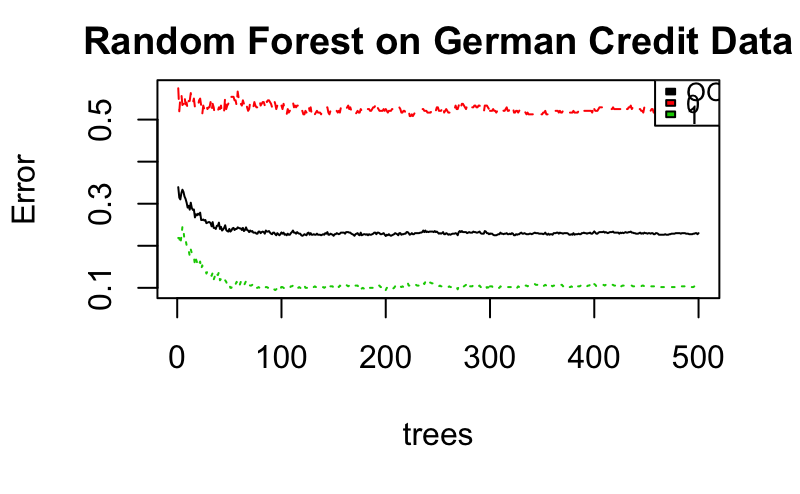

```r
plot(model, main="Random Forest on German Credit Data")
legend("topright", colnames(model$err.rate), col=1:3, cex = 0.8, fill=1:3)
```